# Project Study

2025-05-08

# 1 Research Question

- **Ursprüngliche Frage:** “Are younger people more politically competent because of greater media consumption, or despite lower political trust?”

–> umgeändert zu: *“Do media consumption or political trust affect political competency differently among different age groups?”*

- **Problem:** Political competent variable (polcmpl) only available from rounds 1-4, media variables only available from rounds 8-11 –> new research question necessary
- Erste mögliche alternative Frage: *“Are younger people more interested in politics because of higher media use, despite lower trust in politicians?”* –> Outcome variable ist political interest
- Zweite mögliche alternativeFrage: *“How does higher media consumption affect political trust among different age groups and what role does political interest in this?”* –> Outcome variable ist political trust

# 2 Raw Data & Variables

## 2.1 Dataset

```r
head(dt_raw)
```

```
## # A tibble: 6 × 632
##   name      essround edition proddate    idno cntry      dweight pspwght pweight
##   <chr>        <dbl> <chr>   <chr>      <dbl> <chr+lbl>    <dbl>   <dbl>   <dbl>
## 1 ESS1e06_7        1 6.7     23.11.2023     1 AT [Austr…   0.945   0.941   0.271
## 2 ESS1e06_7        1 6.7     23.11.2023     2 AT [Austr…   0.473   0.470   0.271
## 3 ESS1e06_7        1 6.7     23.11.2023     3 AT [Austr…   0.945   1.39    0.271
## 4 ESS1e06_7        1 6.7     23.11.2023     4 AT [Austr…   0.945   1.38    0.271
## 5 ESS1e06_7        1 6.7     23.11.2023     6 AT [Austr…   1.89    1.44    0.271
## 6 ESS1e06_7        1 6.7     23.11.2023     7 AT [Austr…   0.945   1.39    0.271
## # ℹ 623 more variables: anweight <dbl>, prob <dbl>, stratum <dbl>, psu <dbl>,
## #   netuse <dbl+lbl>, netusoft <dbl+lbl>, netustm <dbl+lbl>, nwspol <dbl+lbl>,
## #   nwsppol <dbl+lbl>, nwsptot <dbl+lbl>, pplfair <dbl+lbl>, pplhlp <dbl+lbl>,
## #   ppltrst <dbl+lbl>, rdpol <dbl+lbl>, rdtot <dbl+lbl>, tvpol <dbl+lbl>,
## #   tvtot <dbl+lbl>, actrolg <dbl+lbl>, actrolga <dbl+lbl>, badge <dbl+lbl>,
## #   bctprd <dbl+lbl>, bghtprd <dbl+lbl>, clsprty <dbl+lbl>, contplt <dbl+lbl>,
## #   cptppol <dbl+lbl>, cptppola <dbl+lbl>, dclagr <dbl+lbl>, …
```

```r
#view(dt_raw)
nrow(dt_raw)
```

```
## [1] 530711
```

```r
ncol(dt_raw)
```

```
## [1] 632
```

## 2.2 Variables we are working with

### 2.2.1 Dependent Variables

**polcmp** (perceived political complexity)

```r
table(dt_raw$polcmpl, useNA = "always")
```

```
##
##      1      2      3      4      5   <NA>
##  15618  36832  66260  38952  27485 345564
```

```r
#polcmpl
dt_raw %>%
  summarise(
    mean = mean(polcmpl, na.rm = TRUE),
    sd = sd(polcmpl, na.rm = TRUE),
    min = min(polcmpl, na.rm = TRUE),
    max = max(polcmpl, na.rm = TRUE),
    n = sum(!is.na(polcmpl))
  )
```

```
## # A tibble: 1 × 5
##    mean    sd min       max                 n
##   <dbl> <dbl> <dbl+lbl> <dbl+lbl>       <int>
## 1  3.14  1.15 1 [Never] 5 [Frequently] 185147
```

-> perceived political complexity, only ESS round 1-4 -> not useful for us

**polintr** (political interest)

```r
table(dt_raw$polintr, useNA = "always")
```

```
##
##      1      2      3      4   <NA>
##  57587 184614 184677 102136   1697
```

```r
#polintr
dt_raw %>%
  summarise(
    mean = mean(polintr, na.rm = TRUE),
    sd = sd(polintr, na.rm = TRUE),
    min = min(polintr, na.rm = TRUE),
    max = max(polintr, na.rm = TRUE),
    n = sum(!is.na(polintr))
  )
```

```
## # A tibble: 1 × 5
##    mean    sd min                 max                            n
##   <dbl> <dbl> <dbl+lbl>           <dbl+lbl>                  <int>
## 1  2.63 0.915 1 [Very interested] 4 [Not at all interested] 529014
```

### 2.2.2 Independent Variables

**agea** (age group)

```r
table(dt_raw$agea, useNA = "always")
```

```
##
##   13   14   15   16   17   18   19   20   21   22   23   24   25   26   27   28
##    1    9 3024 5923 6542 6714 6847 6526 6793 6886 6783 6970 6938 7164 7145 7317
##   29   30   31   32   33   34   35   36   37   38   39   40   41   42   43   44
## 7496 7771 7980 7943 8149 8286 8494 8495 8510 8621 8641 9106 8950 8811 8751 8768
##   45   46   47   48   49   50   51   52   53   54   55   56   57   58   59   60
## 8775 8872 8724 8912 8948 9067 8915 9166 9049 8938 9102 9176 8901 8916 8966 8993
##   61   62   63   64   65   66   67   68   69   70   71   72   73   74   75   76
## 8575 8599 8432 8423 8340 8291 8008 7878 7549 7405 6998 6641 6396 5856 5874 5267
##   77   78   79   80   81   82   83   84   85   86   87   88   89   90   91   92
## 4995 4461 4222 4067 3554 3206 2782 2337 1992 1714 1355 1054  881 1236  327  202
##   93   94   95   96   97   98   99  100  101  102  103  104  105  110  114  123
##  160  110   73   38   21   14   12    8    5    8    3    1    2    1    1    1
## <NA>
## 3562
```

```r
#agea
dt_raw %>%
  summarise(
    mean = mean(agea, na.rm = TRUE),
    sd = sd(agea, na.rm = TRUE),
    min = min(agea, na.rm = TRUE),
    max = max(agea, na.rm = TRUE),
    n = sum(!is.na(agea))
  )
```

```
## # A tibble: 1 × 5
##    mean    sd min       max            n
##   <dbl> <dbl> <dbl+lbl> <dbl+lbl>  <int>
## 1  48.8  18.7 13        123       527149
```

-> turn into age group (<30, 30–59, 60+)

**cntry** (country)

```r
table(dt_raw$cntry, useNA = "always")
```

```
##
##    AL    AT    BE    BG    CH    CY    CZ    DE    DK    EE    ES    FI    FR
##  1201 17579 19045 13240 18309  6750 20090 36845 12408 16856 21296 21095 20809
##    GB    GR    HR    HU    IE    IL    IS    IT    LT    LU    LV    ME    MK
## 22663 15315  8098 18760 24250 16218  4817 13043 13017  3187  3921  2478  1429
##    NL    NO    PL    PT    RO    RS    RU    SE    SI    SK    TR    UA    XK
## 20024 17402 19131 19254  2146  5111 12458 19446 14732 12734  4272  9987  1295
##  <NA>
##     0
```

```r
#cntry
dt_raw %>%
  summarise(
    min = min(cntry, na.rm = TRUE),
    max = max(cntry, na.rm = TRUE),
    n = sum(!is.na(cntry))
  )
```

```
## # A tibble: 1 × 3
##   min          max              n
##   <chr+lbl>    <chr+lbl>    <int>
## 1 AL [Albania] XK [Kosovo] 530711
```

**trstplt** (trust in politicians)

```r
table(dt_raw$trstplt, useNA = "always")
```

```
##
##     0     1     2     3     4     5     6     7     8     9    10  <NA>
## 85418 45052 61564 67919 59861 88173 49716 37458 17165  4330  3415 10640
```

```r
#trstplt
dt_raw %>%
  summarise(
    mean = mean(trstplt, na.rm = TRUE),
    sd = sd(trstplt, na.rm = TRUE),
    min = min(trstplt, na.rm = TRUE),
    max = max(trstplt, na.rm = TRUE),
    n = sum(!is.na(trstplt))
  )
```

```
## # A tibble: 1 × 5
##    mean    sd min                 max                      n
##   <dbl> <dbl> <dbl+lbl>           <dbl+lbl>            <int>
## 1  3.51  2.44 0 [No trust at all] 10 [Complete trust] 520071
```

**nwspol** (Time spent on news about politics and current affairs)

```r
table(dt_raw$nwspol, useNA = "always")
```

```
##
##      0      1      2      3      4      5      6      7      8      9     10
##  12202    197    299    215     39   3404     21     34     37     30   7779
##     11     12     13     14     15     16     17     18     19     20     21
##      3     37     11     29   8688      9      9     12     24   7120      4
##     22     23     24     25     26     27     28     29     30     31     32
##      6      6     10    606      1      4     11     57  31691      7     11
##     33     34     35     36     37     38     39     40     41     42     43
##     15      7    372      7      9     29     19   2260      1      1      1
##     44     45     46     47     48     49     50     51     52     53     54
##      2   5196      6      2      6      6    924      1      3      3      2
##     55     56     58     59     60     61     62     63     64     65     66
##     91      3      8     68  43335    120     23     25      4    217      6
##     67     68     69     70     71     72     73     74     75     76     77
##      7     37      4    901     11     14      2      4   1250      2      1
```

[output cut: 166 more lines]

```r
#nwspol
dt_raw %>%
  summarise(
    mean = mean(nwspol, na.rm = TRUE),
    sd = sd(nwspol, na.rm = TRUE),
    min = min(nwspol, na.rm = TRUE),
    max = max(nwspol, na.rm = TRUE),
    n = sum(!is.na(nwspol))
  )
```

```
## # A tibble: 1 × 5
##    mean    sd min       max            n
##   <dbl> <dbl> <dbl+lbl> <dbl+lbl>  <int>
## 1  89.1  140. 0         1440      190926
```

-> Time spent on news about politics and current affairs, only ESS round 8-11

**netustm** (Time spent on internet per day)

```r
table(dt_raw$netustm, useNA = "always")
```

```
##
##      0      1      2      3      4      5      6      7      8      9     10
##    389     21     22     20     13    106     69     29     75     29    533
##     11     12     13     14     15     16     18     19     20     21     23
##      5     12      2     11    945      4      8      1    838      1      1
##     24     25     27     28     29     30     31     34     35     36     38
##      2     56      1      3      8   6292      3      2     51      1      5
##     39     40     42     43     44     45     46     47     48     49     50
##      2    416      2      1      3   1339      3      1      1      3    253
##     55     58     59     60     61     62     63     64     65     67     68
##     26      2     25  18534     51     11     13      2     83      1     10
##     69     70     71     72     73     74     75     78     79     80     83
##      8    250      3      2      1      4    381      1      1    366      1
##     85     86     88     89     90     91     92     93     94     95     96
##     33      1      3      2   7547      4      1      2      1     17      1
```

[output cut: 78 more lines]

```r
#netustm
dt_raw %>%
  summarise(
    mean = mean(netustm, na.rm = TRUE),
    sd = sd(netustm, na.rm = TRUE),
    min = min(netustm, na.rm = TRUE),
    max = max(netustm, na.rm = TRUE),
    n = sum(!is.na(netustm))
  )
```

```
## # A tibble: 1 × 5
##    mean    sd min       max            n
##   <dbl> <dbl> <dbl+lbl> <dbl+lbl>  <int>
## 1  224.  187. 0         1440      141973
```

-> Time spent on internet per day, only ESS round 8-11

**netusoft** (Frequency of internet use)

```r
table(dt_raw$netusoft, useNA = "always")
```

```
##
##      1      2      3      4      5   <NA>
##  28724  10825  10477  17191 126150 337344
```

```r
#netusoft
dt_raw %>%
  summarise(
    mean = mean(netusoft, na.rm = TRUE),
    sd = sd(netusoft, na.rm = TRUE),
    min = min(netusoft, na.rm = TRUE),
    max = max(netusoft, na.rm = TRUE),
    n = sum(!is.na(netusoft))
  )
```

```
## # A tibble: 1 × 5
##    mean    sd min       max                n
##   <dbl> <dbl> <dbl+lbl> <dbl+lbl>      <int>
## 1  4.04  1.51 1 [Never] 5 [Every day] 193367
```

-> Frequency of internet use, higher = more frequently, only ESS round 8-11

### 2.2.3 Confounders / Mediators

-> For now none

# 3 Data Preparation

Filtering to rounds 8-11, recoding age group and reversing the scale for polintr (higher number = more interested)

```r
dt_new <- dt_raw %>%
  filter(essround %in% 8:11) %>%
  mutate(
    age_group = case_when(
      agea < 30 ~ "<30",
      agea >= 30 & agea <= 59 ~ "30–59",
      agea >= 60 ~ "60+"
    ))  %>%
  mutate(
    age_group = factor(age_group, levels = c("<30", "30–59", "60+")),
    polintr_rev = 5 - polintr  # higher = more interested
    )

#age_group
table(dt_new$age_group, useNA = "always")
```

```
##
##   <30 30–59   60+  <NA>
## 31509 92394 67859  1985
```

# 4 Descriptive Statistics

## 4.1 Summary statistics of polintr_rev by country (code for just one variable)

```r
dt_new %>%
  group_by(cntry) %>%
  summarise(mean   = mean(polintr_rev, na.rm = TRUE),
            median = median(polintr_rev, na.rm = TRUE),
            Q5     = quantile(polintr_rev, .05, na.rm = TRUE),
            Q95    = quantile(polintr_rev, .95, na.rm = TRUE))
```

```
## # A tibble: 33 × 5
##    cntry             mean median    Q5   Q95
##    <chr+lbl>        <dbl>  <dbl> <dbl> <dbl>
##  1 AT [Austria]      2.63      3     1     4
##  2 BE [Belgium]      2.40      2     1     4
##  3 BG [Bulgaria]     2.19      2     1     4
##  4 CH [Switzerland]  2.63      3     1     4
##  5 CY [Cyprus]       2.14      2     1     4
##  6 CZ [Czechia]      1.87      2     1     3
##  7 DE [Germany]      2.83      3     2     4
##  8 DK [Denmark]      2.87      3     2     4
##  9 EE [Estonia]      2.35      2     1     4
## 10 ES [Spain]        2.31      2     1     4
## # ℹ 23 more rows
```

## 4.2 Summary statistics of all variables by country (code for all variables)

```r
dt_new %>%
  group_by(cntry) %>%
  summarise(across(
    c(polintr_rev, trstplt, nwspol, netustm, netusoft),
    list(mean = ~mean(.x, na.rm = TRUE),
         median = ~median(.x, na.rm = TRUE),
         Q5 = ~quantile(.x, 0.05, na.rm = TRUE),
         Q95 = ~quantile(.x, 0.95, na.rm = TRUE))
  ))
```

```
## # A tibble: 33 × 21
##    cntry      polintr_rev_mean polintr_rev_median polintr_rev_Q5 polintr_rev_Q95
##    <chr+lbl>             <dbl>              <dbl>          <dbl>           <dbl>
##  1 AT [Austr…             2.63                  3              1               4
##  2 BE [Belgi…             2.40                  2              1               4
##  3 BG [Bulga…             2.19                  2              1               4
##  4 CH [Switz…             2.63                  3              1               4
##  5 CY [Cypru…             2.14                  2              1               4
##  6 CZ [Czech…             1.87                  2              1               3
##  7 DE [Germa…             2.83                  3              2               4
##  8 DK [Denma…             2.87                  3              2               4
##  9 EE [Eston…             2.35                  2              1               4
## 10 ES [Spain]             2.31                  2              1               4
## # ℹ 23 more rows
## # ℹ 16 more variables: trstplt_mean <dbl>, trstplt_median <dbl>,
## #   trstplt_Q5 <dbl>, trstplt_Q95 <dbl>, nwspol_mean <dbl>,
## #   nwspol_median <dbl>, nwspol_Q5 <dbl>, nwspol_Q95 <dbl>, netustm_mean <dbl>,
## #   netustm_median <dbl>, netustm_Q5 <dbl>, netustm_Q95 <dbl>,
## #   netusoft_mean <dbl>, netusoft_median <dbl>, netusoft_Q5 <dbl>,
## #   netusoft_Q95 <dbl>
```

## 4.3 Summary statistics of variables by age group

```r
dt_new %>%
  group_by(age_group) %>%
  summarise(across(
    c(polintr_rev, trstplt, nwspol, netustm, netusoft),
    list(mean = ~mean(.x, na.rm = TRUE),
         median = ~median(.x, na.rm = TRUE),
         Q5 = ~quantile(.x, 0.05, na.rm = TRUE),
         Q95 = ~quantile(.x, 0.95, na.rm = TRUE))
  ))
```

```
## # A tibble: 4 × 21
##   age_group polintr_rev_mean polintr_rev_median polintr_rev_Q5 polintr_rev_Q95
##   <fct>                <dbl>              <dbl>          <dbl>           <dbl>
## 1 <30                   2.14                  2              1               4
## 2 30–59                 2.36                  2              1               4
## 3 60+                   2.51                  3              1               4
## 4 <NA>                  2.35                  2              1               4
## # ℹ 16 more variables: trstplt_mean <dbl>, trstplt_median <dbl>,
## #   trstplt_Q5 <dbl>, trstplt_Q95 <dbl>, nwspol_mean <dbl>,
## #   nwspol_median <dbl>, nwspol_Q5 <dbl>, nwspol_Q95 <dbl>, netustm_mean <dbl>,
## #   netustm_median <dbl>, netustm_Q5 <dbl>, netustm_Q95 <dbl>,
## #   netusoft_mean <dbl>, netusoft_median <dbl>, netusoft_Q5 <dbl>,
## #   netusoft_Q95 <dbl>
```

## 4.4 Plotting polintr_rev vs. age group

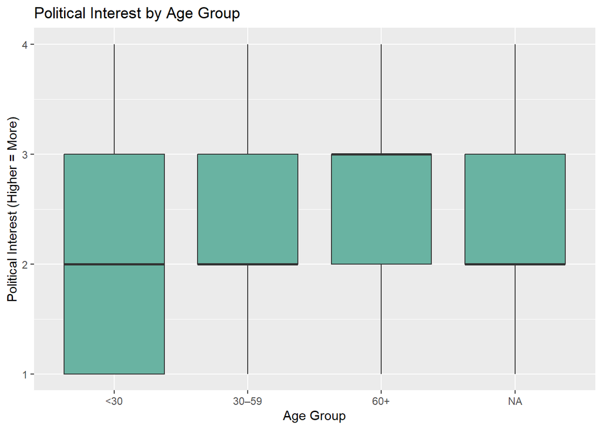

```r
ggplot(dt_new, aes(x = age_group, y = polintr_rev)) +
  geom_boxplot(fill = "#69b3a2") +
  labs(title = "Political Interest by Age Group",
       y = "Political Interest (Higher = More)", x = "Age Group")
```

## 4.5 Plotting average political trust vs. age group

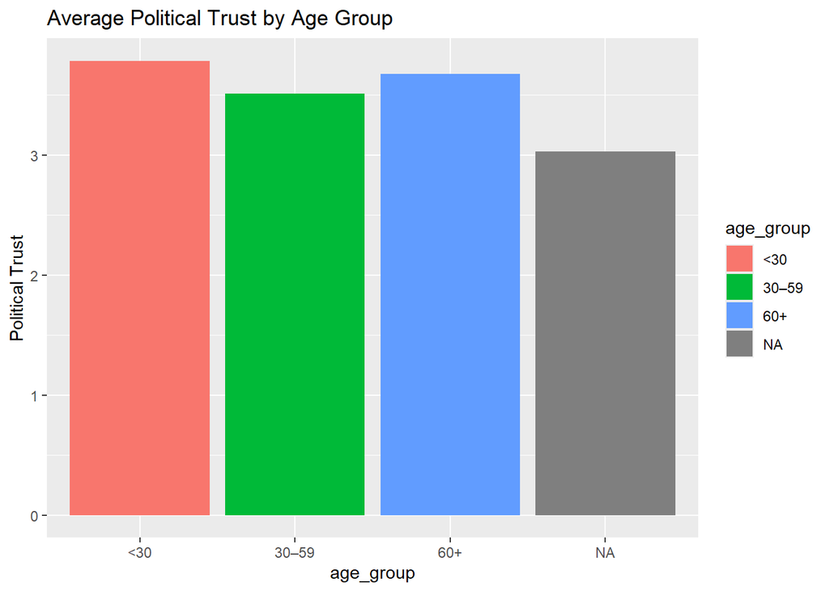

```r
dt_new %>%
  group_by(age_group) %>%
  summarise(mean_trust = mean(trstplt, na.rm = TRUE)) %>%
  ggplot(aes(x = age_group, y = mean_trust, fill = age_group)) +
  geom_col() +
  labs(title = "Average Political Trust by Age Group", y = "Political Trust")
```

## 4.6 Plotting Media use by age group

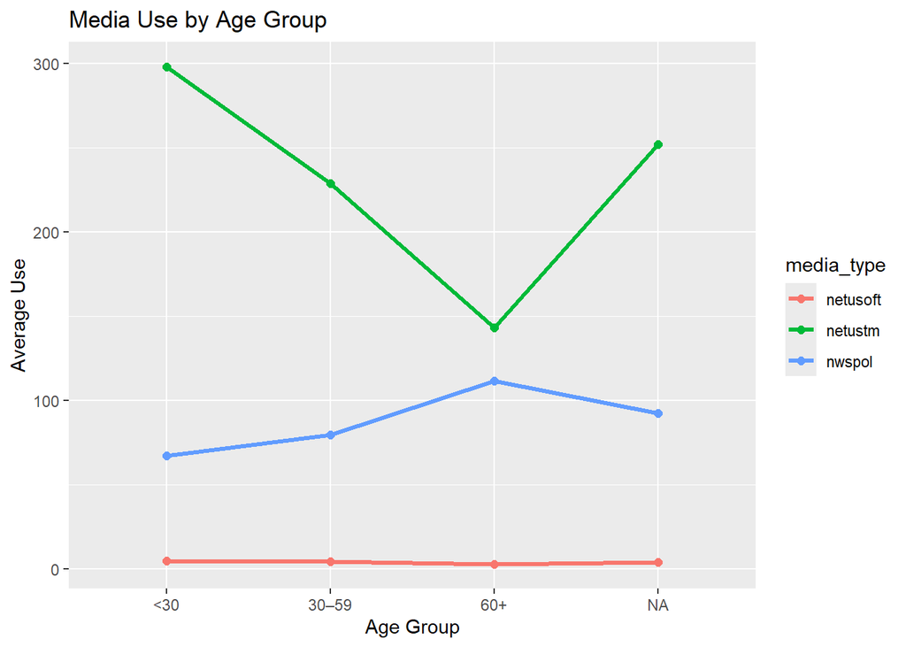

```r
dt_long <- dt_new %>%
  select(age_group, nwspol, netustm, netusoft) %>%
  pivot_longer(cols = c(nwspol, netustm, netusoft), names_to = "media_type", values_to = "value")

dt_long %>%
  group_by(age_group, media_type) %>%
  summarise(mean_value = mean(value, na.rm = TRUE)) %>%
  ggplot(aes(x = age_group, y = mean_value, color = media_type, group = media_type)) +
  geom_line(size = 1.2) +
  geom_point(size = 2) +
  labs(title = "Media Use by Age Group", y = "Average Use", x = "Age Group")
```

## 4.7 Plotting political interest vs. trust (colored by age group)

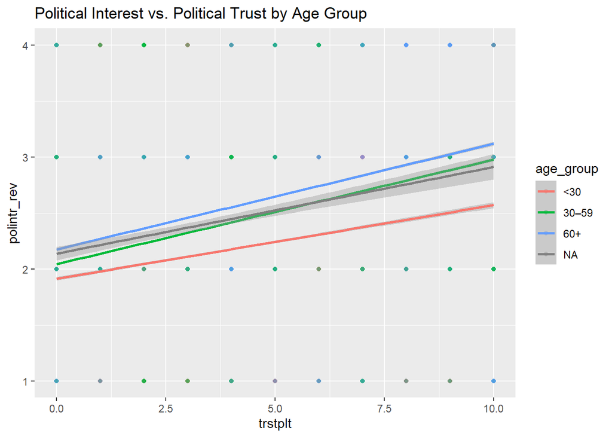

```r
ggplot(dt_new, aes(x = trstplt, y = polintr_rev, color = age_group)) +
  geom_point(alpha = 0.3) +
  geom_smooth(method = "lm") +
  labs(title = "Political Interest vs. Political Trust by Age Group")
```

## 4.8 Plotting political interest vs. time spent on news on politics by age group

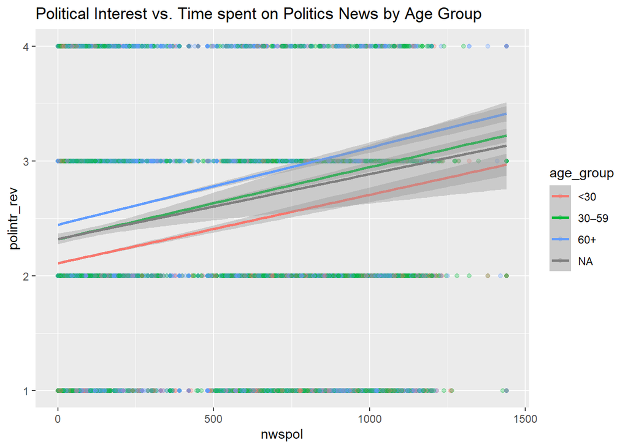

```r
ggplot(dt_new, aes(x = nwspol, y = polintr_rev, color = age_group)) +
  geom_point(alpha = 0.3) +
  geom_smooth(method = "lm") +
  labs(title = "Political Interest vs. Time spent on Politics News by Age Group")
```

## 4.9 Plotting political interest vs. time spent on internet by age group

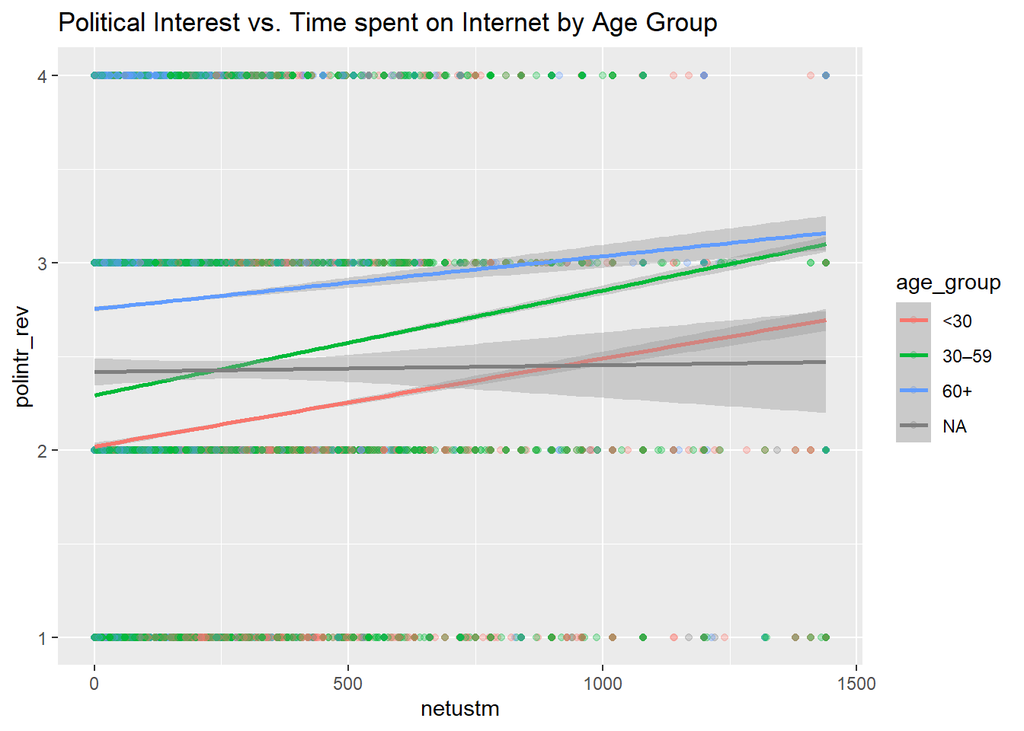

```r
ggplot(dt_new, aes(x = netustm, y = polintr_rev, color = age_group)) +
  geom_point(alpha = 0.3) +
  geom_smooth(method = "lm") +
  labs(title = "Political Interest vs. Time spent on Internet by Age Group")
```

## 4.10 Plotting political trust vs. time spent on internet by age group

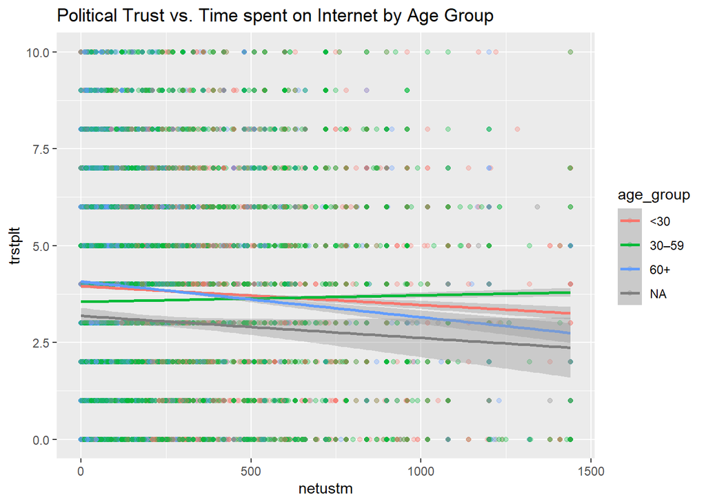

```r
ggplot(dt_new, aes(x = netustm, y = trstplt, color = age_group)) +
  geom_point(alpha = 0.3) +
  geom_smooth(method = "lm") +
  labs(title = "Political Trust vs. Time spent on Internet by Age Group")
```

## 4.11 Plotting political trust vs. time spent on politics by age group

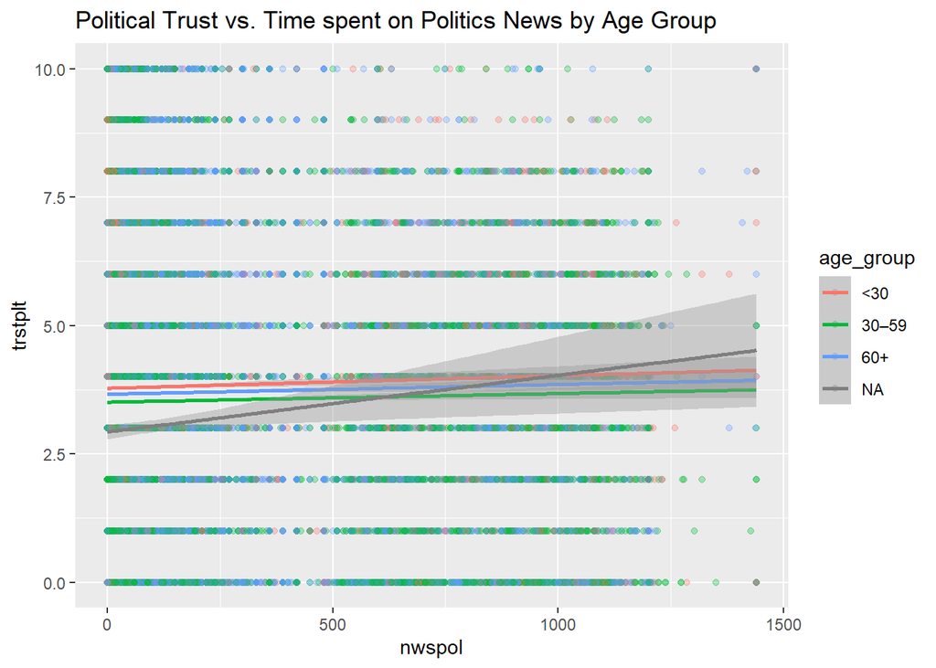

```r
ggplot(dt_new, aes(x = nwspol, y = trstplt, color = age_group)) +
  geom_point(alpha = 0.3) +
  geom_smooth(method = "lm") +
  labs(title = "Political Trust vs. Time spent on Politics News by Age Group")
```

## 4.12 Plotting time spent on internet vs. time spent on politics by age group

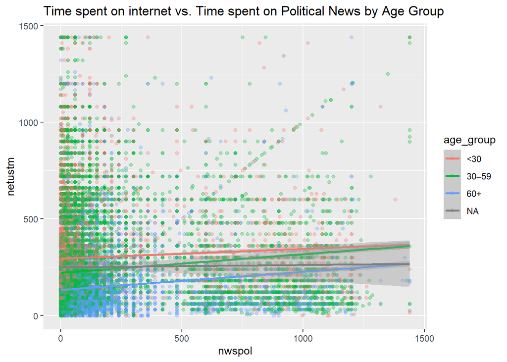

```r
ggplot(dt_new, aes(x = nwspol, y = netustm, color = age_group)) +
  geom_point(alpha = 0.3) +
  geom_smooth(method = "lm") +
  labs(title = "Time spent on internet vs. Time spent on Political News by Age Group")
```

## 4.13 Correlation matrix: polintr, trstplt, nwspol, netustm, netusoft, age

```r
# Select relevant variables
dt_subset <- dt_new %>% select(polintr_rev, trstplt, nwspol, netustm, netusoft, agea)
```

```r
# Calculate correlation matrix (pairwise complete cases)
cor(dt_subset, use = "pairwise.complete.obs")
```

```
##             polintr_rev      trstplt      nwspol     netustm    netusoft
## polintr_rev  1.00000000  0.239316875  0.11068408  0.03012345  0.12974168
## trstplt      0.23931687  1.000000000  0.01197054 -0.01721533  0.06912250
## nwspol       0.11068408  0.011970542  1.00000000  0.03023370 -0.08730776
## netustm      0.03012345 -0.017215330  0.03023370  1.00000000  0.19011099
## netusoft     0.12974168  0.069122503 -0.08730776  0.19011099  1.00000000
## agea         0.13709120  0.003273196  0.12975080 -0.29784020 -0.52275381
##                     agea
## polintr_rev  0.137091204
## trstplt      0.003273196
## nwspol       0.129750802
## netustm     -0.297840203
## netusoft    -0.522753812
## agea         1.000000000
```

# 5 Models

```r
options(scipen = 999) #to get whole numbers in the output
```

## 5.1 Political Interest as outcome variable

### 5.1.1 1. Age group only

```r
mod1 <- lm(polintr_rev ~ age_group, data = dt_new)
summary(mod1)
```

```
##
## Call:
## lm(formula = polintr_rev ~ age_group, data = dt_new)
##
## Residuals:
##     Min      1Q  Median      3Q     Max
## -1.5138 -0.5138 -0.1445  0.6363  1.8555
##
## Coefficients:
##                Estimate Std. Error t value            Pr(>|t|)
## (Intercept)    2.144511   0.005156  415.93 <0.0000000000000002 ***
## age_group30–59 0.219160   0.005971   36.71 <0.0000000000000002 ***
## age_group60+   0.369320   0.006239   59.20 <0.0000000000000002 ***
## ---
## Signif. codes:  0 '***' 0.001 '**' 0.01 '*' 0.05 '.' 0.1 ' ' 1
##
## Residual standard error: 0.9142 on 191352 degrees of freedom
##   (2392 Beobachtungen als fehlend gelöscht)
## Multiple R-squared:  0.0183, Adjusted R-squared:  0.01829
## F-statistic:  1783 on 2 and 191352 DF,  p-value: < 0.00000000000000022
```

- Intercept = 2.145 → This is the mean value of the outcome (e.g. polintr_rev, political interest reversed) for people under 30 (<30).
- age_group30–59 = 0.219 → People aged 30–59 score on average 0.219 points higher than those under 30, all else equal.
- age_group60+ = 0.369 → People aged 60+ score on average 0.369 points higher than those under 30 –> political interest higher for older people

### 5.1.2 2. Adding trstplt as control variable

```r
mod2 <- lm(polintr_rev ~ age_group + trstplt, data = dt_new)
summary(mod2)
```

```
##
## Call:
## lm(formula = polintr_rev ~ age_group + trstplt, data = dt_new)
##
## Residuals:
##      Min       1Q   Median       3Q      Max
## -2.08733 -0.59328 -0.05648  0.62841  2.17688
##
## Coefficients:
##                 Estimate Std. Error t value            Pr(>|t|)
## (Intercept)    1.8231245  0.0059301  307.43 <0.0000000000000002 ***
## age_group30–59 0.2333547  0.0058394   39.96 <0.0000000000000002 ***
## age_group60+   0.3695320  0.0060986   60.59 <0.0000000000000002 ***
## trstplt        0.0894676  0.0008224  108.79 <0.0000000000000002 ***
## ---
## Signif. codes:  0 '***' 0.001 '**' 0.01 '*' 0.05 '.' 0.1 ' ' 1
##
## Residual standard error: 0.8842 on 188575 degrees of freedom
##   (5168 Beobachtungen als fehlend gelöscht)
## Multiple R-squared:  0.07548,    Adjusted R-squared:  0.07547
## F-statistic:  5132 on 3 and 188575 DF,  p-value: < 0.00000000000000022
```

- Age and trust both positively predict political interest (reversed scale)
- Older people and more trusting people are more interested in politics (as measured by reversed scale)

### 5.1.3 3. Interaction with trust to see if trust matters more/less by age

```r
mod3 <- lm(polintr_rev ~ age_group + trstplt + age_group * trstplt , data = dt_new)
summary(mod3)
```

```
##
## Call:
## lm(formula = polintr_rev ~ age_group + trstplt + age_group *
##     trstplt, data = dt_new)
##
## Residuals:
##      Min       1Q   Median       3Q      Max
## -2.11909 -0.60316 -0.04436  0.63682  2.08722
##
## Coefficients:
##                        Estimate Std. Error t value            Pr(>|t|)
## (Intercept)            1.912781   0.009326  205.11 <0.0000000000000002 ***
## age_group30–59         0.129736   0.010630   12.21 <0.0000000000000002 ***
## age_group60+           0.261420   0.011124   23.50 <0.0000000000000002 ***
## trstplt                0.065788   0.002072   31.76 <0.0000000000000002 ***
## age_group30–59:trstplt 0.027652   0.002388   11.58 <0.0000000000000002 ***
## age_group60+:trstplt   0.028700   0.002479   11.58 <0.0000000000000002 ***
## ---
## Signif. codes:  0 '***' 0.001 '**' 0.01 '*' 0.05 '.' 0.1 ' ' 1
##
## Residual standard error: 0.8839 on 188573 degrees of freedom
##   (5168 Beobachtungen als fehlend gelöscht)
## Multiple R-squared:  0.07625,    Adjusted R-squared:  0.07622
## F-statistic:  3113 on 5 and 188573 DF,  p-value: < 0.00000000000000022
```

- model tells us how the slope for trust differs by age group
- 30–59-year-olds: Slope = 0.066 + 0.028 = 0.094 -> They are more responsive to political trust than under-30s
- 60+ year-olds: Slope = 0.066 + 0.029 = 0.095 -> Also more responsive than under-30s
- Political trust predicts political interest more strongly in older age groups than in younger people

### 5.1.4 4. adding media use as predictors

```r
mod4 <- lm(polintr_rev ~ age_group + trstplt + nwspol + netustm + netusoft, data = dt_new)
summary(mod4)
```

```
##
## Call:
## lm(formula = polintr_rev ~ age_group + trstplt + nwspol + netustm +
##     netusoft, data = dt_new)
##
## Residuals:
##      Min       1Q   Median       3Q      Max
## -2.68208 -0.58357 -0.02324  0.60147  2.30352
##
## Coefficients:
##                  Estimate Std. Error t value            Pr(>|t|)
## (Intercept)    1.15574765 0.03265951   35.39 <0.0000000000000002 ***
## age_group30–59 0.29710482 0.00597851   49.70 <0.0000000000000002 ***
## age_group60+   0.66409075 0.00732027   90.72 <0.0000000000000002 ***
## trstplt        0.08378012 0.00094552   88.61 <0.0000000000000002 ***
## nwspol         0.00069456 0.00001735   40.04 <0.0000000000000002 ***
## netustm        0.00044057 0.00001299   33.92 <0.0000000000000002 ***
## netusoft       0.10633714 0.00657064   16.18 <0.0000000000000002 ***
## ---
## Signif. codes:  0 '***' 0.001 '**' 0.01 '*' 0.05 '.' 0.1 ' ' 1
##
## Residual standard error: 0.8537 on 137486 degrees of freedom
##   (56254 Beobachtungen als fehlend gelöscht)
## Multiple R-squared:  0.1241, Adjusted R-squared:  0.1241
## F-statistic:  3247 on 6 and 137486 DF,  p-value: < 0.00000000000000022
```

- small coefficients but also small unit scale of variables (measured in minutes)
- Intercept: 1.1557 is predicted political interest (reversed) for reference group (age <30, with 0 trust/media use)
- age_group30–59: +0.297 -> This age group scores 0.297 higher than under 30s, holding all else constant
- age_group60+: +0.664 -> This group scores 0.664 higher than under 30s
- trstplt: +0.0838 -> For each one-unit increase in political trust, political interest goes up by 0.084
- nwspol (news about politics freq): +0.00069 -> For each unit increase, very small increase in interest (measured in minutes)
- netustm (internet use) +0.00044 Also small but significant effect (measured in minutes)
- netusoft (internet use) +0.106 One of the larger media effects (measured on scale)

### 5.1.5 5. Full interaction model: adding age*media interaction to see if the effect of news consumption differs by age group

```r
mod5 <- lm(polintr_rev ~ age_group * (trstplt + nwspol + netustm + netusoft), data = dt_new)
summary(mod5)
```

```
##
## Call:
## lm(formula = polintr_rev ~ age_group * (trstplt + nwspol + netustm +
##     netusoft), data = dt_new)
##
## Residuals:
##      Min       1Q   Median       3Q      Max
## -2.91715 -0.59156 -0.01987  0.60907  2.27631
##
## Coefficients:
##                             Estimate   Std. Error t value             Pr(>|t|)
## (Intercept)              1.287941921  0.104319854  12.346 < 0.0000000000000002
## age_group30–59           0.051582162  0.114591616   0.450                0.653
## age_group60+             0.597109090  0.114594090   5.211         0.0000001885
## trstplt                  0.066137088  0.002075624  31.864 < 0.0000000000000002
## nwspol                   0.000615674  0.000036101  17.054 < 0.0000000000000002
## netustm                  0.000459521  0.000025747  17.848 < 0.0000000000000002
## netusoft                 0.093129227  0.021154498   4.402         0.0000107172
## age_group30–59:trstplt   0.024535759  0.002427251  10.108 < 0.0000000000000002
## age_group60+:trstplt     0.015785560  0.002868552   5.503         0.0000000374
## age_group30–59:nwspol    0.000043931  0.000043041   1.021                0.307
## age_group60+:nwspol      0.000261989  0.000051592   5.078         0.0000003817
## age_group30–59:netustm   0.000009709  0.000030608   0.317                0.751
## age_group60+:netustm    -0.000236824  0.000044610  -5.309         0.0000001106
## age_group30–59:netusoft  0.030536801  0.023291130   1.311                0.190
## age_group60+:netusoft    0.003484796  0.023339042   0.149                0.881
##
## (Intercept)             ***
## age_group30–59
## age_group60+            ***
## trstplt                 ***
## nwspol                  ***
## netustm                 ***
## netusoft                ***
## age_group30–59:trstplt  ***
## age_group60+:trstplt    ***
## age_group30–59:nwspol
## age_group60+:nwspol     ***
## age_group30–59:netustm
## age_group60+:netustm    ***
## age_group30–59:netusoft
## age_group60+:netusoft
## ---
## Signif. codes:  0 '***' 0.001 '**' 0.01 '*' 0.05 '.' 0.1 ' ' 1
##
## Residual standard error: 0.8532 on 137478 degrees of freedom
##   (56254 Beobachtungen als fehlend gelöscht)
## Multiple R-squared:  0.1253, Adjusted R-squared:  0.1252
## F-statistic:  1406 on 14 and 137478 DF,  p-value: < 0.00000000000000022
```

### 5.1.6 6. Also possible: Stepwise interaction for each media variable individually

```r
mod5b <- lm(polintr_rev ~ age_group + trstplt + nwspol + age_group * nwspol, data = dt_new)
summary(mod5b)
```

```
##
## Call:
## lm(formula = polintr_rev ~ age_group + trstplt + nwspol + age_group *
##     nwspol, data = dt_new)
##
## Residuals:
##      Min       1Q   Median       3Q      Max
## -2.63394 -0.58987 -0.05842  0.61302  2.20879
##
## Coefficients:
##                         Estimate Std. Error t value            Pr(>|t|)
## (Intercept)           1.79121126 0.00640686 279.577 <0.0000000000000002 ***
## age_group30–59        0.22225784 0.00655769  33.893 <0.0000000000000002 ***
## age_group60+          0.33527314 0.00710390  47.196 <0.0000000000000002 ***
## trstplt               0.08880612 0.00082479 107.671 <0.0000000000000002 ***
## nwspol                0.00055908 0.00003525  15.862 <0.0000000000000002 ***
## age_group30–59:nwspol 0.00005052 0.00004142   1.220               0.223
## age_group60+:nwspol   0.00008613 0.00004277   2.014               0.044 *
## ---
## Signif. codes:  0 '***' 0.001 '**' 0.01 '*' 0.05 '.' 0.1 ' ' 1
##
## Residual standard error: 0.88 on 186065 degrees of freedom
##   (7675 Beobachtungen als fehlend gelöscht)
## Multiple R-squared:  0.08364,    Adjusted R-squared:  0.08361
## F-statistic:  2831 on 6 and 186065 DF,  p-value: < 0.00000000000000022
```

### 5.1.7 7. interaction between media*trust to explore whether the impact of trust on political interest depends on media usage patterns.

```r
mod6 <- lm(polintr_rev ~ age_group + trstplt * (nwspol + netustm + netusoft), data = dt_new)
summary(mod6)
```

```
##
## Call:
## lm(formula = polintr_rev ~ age_group + trstplt * (nwspol + netustm +
##     netusoft), data = dt_new)
##
## Residuals:
##      Min       1Q   Median       3Q      Max
## -2.73788 -0.58590 -0.02086  0.60190  2.28776
##
## Coefficients:
##                      Estimate   Std. Error t value             Pr(>|t|)
## (Intercept)       1.319327197  0.057121639  23.097 < 0.0000000000000002 ***
## age_group30–59    0.297128249  0.005978213  49.702 < 0.0000000000000002 ***
## age_group60+      0.664378984  0.007324971  90.701 < 0.0000000000000002 ***
## trstplt           0.039554600  0.012700386   3.114             0.001843 **
## nwspol            0.000769328  0.000030625  25.121 < 0.0000000000000002 ***
## netustm           0.000458665  0.000022033  20.817 < 0.0000000000000002 ***
## netusoft          0.070622411  0.011727954   6.022        0.00000000173 ***
## trstplt:nwspol   -0.000020383  0.000006891  -2.958             0.003098 **
## trstplt:netustm  -0.000004978  0.000005018  -0.992             0.321150
## trstplt:netusoft  0.009658544  0.002625690   3.678             0.000235 ***
## ---
## Signif. codes:  0 '***' 0.001 '**' 0.01 '*' 0.05 '.' 0.1 ' ' 1
##
## Residual standard error: 0.8537 on 137483 degrees of freedom
##   (56254 Beobachtungen als fehlend gelöscht)
## Multiple R-squared:  0.1243, Adjusted R-squared:  0.1242
## F-statistic:  2168 on 9 and 137483 DF,  p-value: < 0.00000000000000022
```

### 5.1.8 8. Fully Saturated Model (all Interactions) but only if we have enough data and want to explore complex interactions

```r
mod7 <- lm(polintr_rev ~ age_group * (nwspol + netustm + netusoft) +
                            trstplt * (nwspol + netustm + netusoft), data = dt_new)
summary(mod7)
```

```
##
## Call:
## lm(formula = polintr_rev ~ age_group * (nwspol + netustm + netusoft) +
##     trstplt * (nwspol + netustm + netusoft), data = dt_new)
##
## Residuals:
##      Min       1Q   Median       3Q      Max
## -2.93779 -0.58635 -0.02014  0.60037  2.29022
##
## Coefficients:
##                              Estimate    Std. Error t value
## (Intercept)              1.4094695418  0.1151942265  12.236
## age_group30–59           0.1150986435  0.1144596386   1.006
## age_group60+             0.6580907333  0.1141576575   5.765
## nwspol                   0.0006947158  0.0000450635  15.416
## netustm                  0.0004839593  0.0000311880  15.518
## netusoft                 0.0518976597  0.0234917057   2.209
## trstplt                  0.0355255288  0.0127533434   2.786
## age_group30–59:nwspol    0.0000413087  0.0000431439   0.957
## age_group60+:nwspol      0.0002645958  0.0000515981   5.128
## age_group30–59:netustm   0.0000001515  0.0000306060   0.005
## age_group60+:netustm    -0.0002449393  0.0000445913  -5.493
## age_group30–59:netusoft  0.0369919769  0.0233238225   1.586
## age_group60+:netusoft    0.0037762060  0.0233450760   0.162
## nwspol:trstplt          -0.0000214320  0.0000069098  -3.102
## netustm:trstplt         -0.0000040040  0.0000050203  -0.798
## netusoft:trstplt         0.0104175506  0.0026365795   3.951
##                                     Pr(>|t|)
## (Intercept)             < 0.0000000000000002 ***
## age_group30–59                       0.31462
## age_group60+                    0.0000000082 ***
## nwspol                  < 0.0000000000000002 ***
## netustm                 < 0.0000000000000002 ***
## netusoft                             0.02716 *
## trstplt                              0.00534 **
## age_group30–59:nwspol                0.33834
## age_group60+:nwspol             0.0000002932 ***
## age_group30–59:netustm               0.99605
## age_group60+:netustm            0.0000000396 ***
## age_group30–59:netusoft              0.11274
## age_group60+:netusoft                0.87150
## nwspol:trstplt                       0.00192 **
## netustm:trstplt                      0.42512
## netusoft:trstplt                0.0000778117 ***
## ---
## Signif. codes:  0 '***' 0.001 '**' 0.01 '*' 0.05 '.' 0.1 ' ' 1
##
## Residual standard error: 0.8534 on 137477 degrees of freedom
##   (56254 Beobachtungen als fehlend gelöscht)
## Multiple R-squared:  0.1248, Adjusted R-squared:  0.1247
## F-statistic:  1307 on 15 and 137477 DF,  p-value: < 0.00000000000000022
```

### 5.1.9 Comparing all models

```r
modelsummary(
  list(
    "Model 1" = mod1,
    "Model 2" = mod2,
    "Model 3" = mod3,
    "Model 4" = mod4,
    "Model 5" = mod5,
    "Model 6" = mod6,
    "Model 7" = mod7
  ),
  statistic = "std.error",  # or "conf.int" if you prefer confidence intervals
  stars = TRUE,
  title = "Table: Predicting Political Interest"
)
```

|  | Model 1 | Model 2 | Model 3 | Model 4 | Model 5 | Model 6 | Model 7 |
| --- | --- | --- | --- | --- | --- | --- | --- |
| (Intercept) | 2.145*** | 1.823*** | 1.913*** | 1.156*** | 1.288*** | 1.319*** | 1.409*** |
|  | (0.005) | (0.006) | (0.009) | (0.033) | (0.104) | (0.057) | (0.115) |
| age_group30–59 | 0.219*** | 0.233*** | 0.130*** | 0.297*** | 0.052 | 0.297*** | 0.115 |
|  | (0.006) | (0.006) | (0.011) | (0.006) | (0.115) | (0.006) | (0.114) |
| age_group60+ | 0.369*** | 0.370*** | 0.261*** | 0.664*** | 0.597*** | 0.664*** | 0.658*** |
|  | (0.006) | (0.006) | (0.011) | (0.007) | (0.115) | (0.007) | (0.114) |
| trstplt |  | 0.089*** | 0.066*** | 0.084*** | 0.066*** | 0.040** | 0.036** |
|  |  | (0.001) | (0.002) | (0.001) | (0.002) | (0.013) | (0.013) |
| age_group30–59 × trstplt |  |  | 0.028*** |  | 0.025*** |  |  |
|  |  |  | (0.002) |  | (0.002) |  |  |
| age_group60+ × trstplt |  |  | 0.029*** |  | 0.016*** |  |  |
|  |  |  | (0.002) |  | (0.003) |  |  |
| nwspol |  |  |  | 0.001*** | 0.001*** | 0.001*** | 0.001*** |
|  |  |  |  | (0.000) | (0.000) | (0.000) | (0.000) |
| netustm |  |  |  | 0.000*** | 0.000*** | 0.000*** | 0.000*** |
|  |  |  |  | (0.000) | (0.000) | (0.000) | (0.000) |
| netusoft |  |  |  | 0.106*** | 0.093*** | 0.071*** | 0.052* |
|  |  |  |  | (0.007) | (0.021) | (0.012) | (0.023) |
| age_group30–59 × nwspol |  |  |  |  | 0.000 |  | 0.000 |
|  |  |  |  |  | (0.000) |  | (0.000) |
| age_group60+ × nwspol |  |  |  |  | 0.000*** |  | 0.000*** |
|  |  |  |  |  | (0.000) |  | (0.000) |
| age_group30–59 × netustm |  |  |  |  | 0.000 |  | 0.000 |
|  |  |  |  |  | (0.000) |  | (0.000) |
| age_group60+ × netustm |  |  |  |  | -0.000*** |  | -0.000*** |
|  |  |  |  |  | (0.000) |  | (0.000) |
| age_group30–59 × netusoft |  |  |  |  | 0.031 |  | 0.037 |
|  |  |  |  |  | (0.023) |  | (0.023) |
| age_group60+ × netusoft |  |  |  |  | 0.003 |  | 0.004 |
|  |  |  |  |  | (0.023) |  | (0.023) |
| trstplt × nwspol |  |  |  |  |  | -0.000** |  |
|  |  |  |  |  |  | (0.000) |  |
| trstplt × netustm |  |  |  |  |  | -0.000 |  |
|  |  |  |  |  |  | (0.000) |  |
| trstplt × netusoft |  |  |  |  |  | 0.010*** |  |
|  |  |  |  |  |  | (0.003) |  |
| nwspol × trstplt |  |  |  |  |  |  | -0.000** |
|  |  |  |  |  |  |  | (0.000) |
| netustm × trstplt |  |  |  |  |  |  | -0.000 |
|  |  |  |  |  |  |  | (0.000) |
| netusoft × trstplt |  |  |  |  |  |  | 0.010*** |
|  |  |  |  |  |  |  | (0.003) |
| Num.Obs. | 191355 | 188579 | 188579 | 137493 | 137493 | 137493 | 137493 |
| R2 | 0.018 | 0.075 | 0.076 | 0.124 | 0.125 | 0.124 | 0.125 |
| R2 Adj. | 0.018 | 0.075 | 0.076 | 0.124 | 0.125 | 0.124 | 0.125 |
| AIC | 508704.4 | 488758.0 | 488606.6 | 346712.3 | 346549.3 | 346694.9 | 346628.0 |
| BIC | 508745.1 | 488808.7 | 488677.7 | 346791.0 | 346706.6 | 346803.1 | 346795.2 |
| Log.Lik. | -254348.212 | -244374.006 | -244296.323 | -173348.175 | -173258.673 | -173336.462 | -173297.022 |
| RMSE | 0.91 | 0.88 | 0.88 | 0.85 | 0.85 | 0.85 | 0.85 |

+ p < 0.1, * p < 0.05, ** p < 0.01, *** p < 0.001

## 5.2 Political Trust as outcome variable (to see if results are more interesting)

### 5.2.1 1. Age group and political interest as control variable

```r
mod8 <- lm(trstplt ~ age_group + polintr_rev, data = dt_new)
summary(mod8)
```

```
##
## Call:
## lm(formula = trstplt ~ age_group + polintr_rev, data = dt_new)
##
## Residuals:
##     Min      1Q  Median      3Q     Max
## -4.9996 -1.9914  0.0086  1.7307  7.3907
##
## Coefficients:
##                 Estimate Std. Error t value            Pr(>|t|)
## (Intercept)     2.359372   0.018973  124.36 <0.0000000000000002 ***
## age_group30–59 -0.410130   0.015900  -25.80 <0.0000000000000002 ***
## age_group60+   -0.348112   0.016706  -20.84 <0.0000000000000002 ***
## polintr_rev     0.660052   0.006067  108.79 <0.0000000000000002 ***
## ---
## Signif. codes:  0 '***' 0.001 '**' 0.01 '*' 0.05 '.' 0.1 ' ' 1
##
## Residual standard error: 2.402 on 188575 degrees of freedom
##   (5168 Beobachtungen als fehlend gelöscht)
## Multiple R-squared:  0.06074,    Adjusted R-squared:  0.06072
## F-statistic:  4065 on 3 and 188575 DF,  p-value: < 0.00000000000000022
```

### 5.2.2 2.Interaction with political interest to see if it matters more/less by age

```r
mod9 <- lm(trstplt ~ age_group + polintr_rev + age_group * polintr_rev , data = dt_new)
summary(mod9)
```

```
##
## Call:
## lm(formula = trstplt ~ age_group + polintr_rev + age_group *
##     polintr_rev, data = dt_new)
##
## Residuals:
##     Min      1Q  Median      3Q     Max
## -4.7008 -1.9992  0.0008  1.7455  7.4456
##
## Coefficients:
##                            Estimate Std. Error t value            Pr(>|t|)
## (Intercept)                 2.71082    0.03615  74.990 <0.0000000000000002 ***
## age_group30–59             -0.85656    0.04253 -20.138 <0.0000000000000002 ***
## age_group60+               -0.74063    0.04490 -16.495 <0.0000000000000002 ***
## polintr_rev                 0.49748    0.01547  32.151 <0.0000000000000002 ***
## age_group30–59:polintr_rev  0.20263    0.01782  11.371 <0.0000000000000002 ***
## age_group60+:polintr_rev    0.17885    0.01837   9.737 <0.0000000000000002 ***
## ---
## Signif. codes:  0 '***' 0.001 '**' 0.01 '*' 0.05 '.' 0.1 ' ' 1
##
## Residual standard error: 2.401 on 188573 degrees of freedom
##   (5168 Beobachtungen als fehlend gelöscht)
## Multiple R-squared:  0.0614, Adjusted R-squared:  0.06138
## F-statistic:  2467 on 5 and 188573 DF,  p-value: < 0.00000000000000022
```

### 5.2.3 3. adding media use as predictors

```r
mod10 <- lm(trstplt ~ age_group + polintr_rev + nwspol + netustm + netusoft, data = dt_new)
summary(mod10)
```

```
##
## Call:
## lm(formula = trstplt ~ age_group + polintr_rev + nwspol + netustm +
##     netusoft, data = dt_new)
##
## Residuals:
##     Min      1Q  Median      3Q     Max
## -5.1165 -1.9482  0.0424  1.7941  7.5793
##
## Coefficients:
##                   Estimate  Std. Error t value             Pr(>|t|)
## (Intercept)     2.35362386  0.09079460  25.923 < 0.0000000000000002 ***
## age_group30–59 -0.40906733  0.01669758 -24.499 < 0.0000000000000002 ***
## age_group60+   -0.31992558  0.02088918 -15.315 < 0.0000000000000002 ***
## polintr_rev     0.64479470  0.00727699  88.607 < 0.0000000000000002 ***
## nwspol         -0.00018710  0.00004840  -3.866             0.000111 ***
## netustm        -0.00044656  0.00003616 -12.349 < 0.0000000000000002 ***
## netusoft        0.04166348  0.01824538   2.284             0.022402 *
## ---
## Signif. codes:  0 '***' 0.001 '**' 0.01 '*' 0.05 '.' 0.1 ' ' 1
##
## Residual standard error: 2.368 on 137486 degrees of freedom
##   (56254 Beobachtungen als fehlend gelöscht)
## Multiple R-squared:  0.05818,    Adjusted R-squared:  0.05814
## F-statistic:  1416 on 6 and 137486 DF,  p-value: < 0.00000000000000022
```

### 5.2.4 4. Full interaction model: adding age*media interaction to see if the effect of news consumption differs by age group

```r
mod11 <- lm(trstplt ~ age_group * (polintr_rev + nwspol + netustm + netusoft), data = dt_new)
summary(mod11)
```

```
##
## Call:
## lm(formula = trstplt ~ age_group * (polintr_rev + nwspol + netustm +
##     netusoft), data = dt_new)
##
## Residuals:
##     Min      1Q  Median      3Q     Max
## -4.9334 -1.9562  0.0366  1.7547  7.7001
##
## Coefficients:
##                                Estimate   Std. Error t value
## (Intercept)                 2.861058757  0.289639856   9.878
## age_group30–59             -1.223372025  0.318334189  -3.843
## age_group60+               -0.670598295  0.319280767  -2.100
## polintr_rev                 0.504685421  0.015904884  31.731
## nwspol                     -0.000067612  0.000100636  -0.672
## netustm                    -0.000722961  0.000071680 -10.086
## netusoft                    0.015875298  0.058700152   0.270
## age_group30–59:polintr_rev  0.187559863  0.018600487  10.084
## age_group60+:polintr_rev    0.143204133  0.022170552   6.459
## age_group30–59:nwspol      -0.000209462  0.000119981  -1.746
## age_group60+:nwspol         0.000003233  0.000144132   0.022
## age_group30–59:netustm      0.000517283  0.000085249   6.068
## age_group60+:netustm       -0.000361986  0.000123795  -2.924
## age_group30–59:netusoft     0.055141374  0.064636468   0.853
## age_group60+:netusoft       0.007504001  0.064776120   0.116
##                                        Pr(>|t|)
## (Intercept)                < 0.0000000000000002 ***
## age_group30–59                         0.000122 ***
## age_group60+                           0.035701 *
## polintr_rev                < 0.0000000000000002 ***
## nwspol                                 0.501678
## netustm                    < 0.0000000000000002 ***
## netusoft                               0.786817
## age_group30–59:polintr_rev < 0.0000000000000002 ***
## age_group60+:polintr_rev         0.000000000106 ***
## age_group30–59:nwspol                  0.080850 .
## age_group60+:nwspol                    0.982103
## age_group30–59:netustm           0.000000001299 ***
## age_group60+:netustm                   0.003455 **
## age_group30–59:netusoft                0.393605
## age_group60+:netusoft                  0.907775
## ---
## Signif. codes:  0 '***' 0.001 '**' 0.01 '*' 0.05 '.' 0.1 ' ' 1
##
## Residual standard error: 2.367 on 137478 degrees of freedom
##   (56254 Beobachtungen als fehlend gelöscht)
## Multiple R-squared:  0.05961,    Adjusted R-squared:  0.05951
## F-statistic: 622.5 on 14 and 137478 DF,  p-value: < 0.00000000000000022
```

- Political interest increases political trust most for older age groups
- Time spent online (netustm) is negatively related to political trust — but this relationship changes with age:
  - It’s less negative for 30–59-year-olds, and more negative for people aged 60+
  - Political news use and soft media use don’t show clear or consistent age-based differences

### 5.2.5 5. interaction between media*political interest to explore whether the impact of interest on trust depends on media usage patterns.

```r
mod12 <- lm(trstplt ~ age_group + polintr_rev * (nwspol + netustm + netusoft), data = dt_new)
summary(mod12)
```

```
##
## Call:
## lm(formula = trstplt ~ age_group + polintr_rev * (nwspol + netustm +
##     netusoft), data = dt_new)
##
## Residuals:
##     Min      1Q  Median      3Q     Max
## -5.1743 -1.9547  0.0384  1.7871  7.5089
##
## Coefficients:
##                         Estimate  Std. Error t value             Pr(>|t|)
## (Intercept)           2.44571127  0.26283706   9.305 < 0.0000000000000002 ***
## age_group30–59       -0.40821616  0.01672181 -24.412 < 0.0000000000000002 ***
## age_group60+         -0.31939556  0.02090852 -15.276 < 0.0000000000000002 ***
## polintr_rev           0.60783100  0.10010879   6.072        0.00000000127 ***
## nwspol                0.00048941  0.00012977   3.771             0.000162 ***
## netustm              -0.00017859  0.00010005  -1.785             0.074270 .
## netusoft             -0.00109093  0.05411883  -0.020             0.983917
## polintr_rev:nwspol   -0.00027879  0.00004989  -5.588        0.00000002295 ***
## polintr_rev:netustm  -0.00010549  0.00003760  -2.806             0.005022 **
## polintr_rev:netusoft  0.01755293  0.02063284   0.851             0.394922
## ---
## Signif. codes:  0 '***' 0.001 '**' 0.01 '*' 0.05 '.' 0.1 ' ' 1
##
## Residual standard error: 2.368 on 137483 degrees of freedom
##   (56254 Beobachtungen als fehlend gelöscht)
## Multiple R-squared:  0.05846,    Adjusted R-squared:  0.0584
## F-statistic: 948.6 on 9 and 137483 DF,  p-value: < 0.00000000000000022
```

- Political interest is a strong predictor of political trust
- Older people are slightly less trusting, controlling for other variables
- Media use interacts with interest:
  - Political interest leads to more trust, but less so among people who are more exposed to political news and who are online more
  - In other words, the more media people consume, the weaker the link between political engagement and trust becomes